# STAT232 Final Project

```r
Box.test(modelfit$residuals, type="Ljung-Box")
```

```
##
##  Box-Ljung test
##
## data:  modelfit$residuals
## X-squared = 0.21656, df = 1, p-value = 0.6417
```

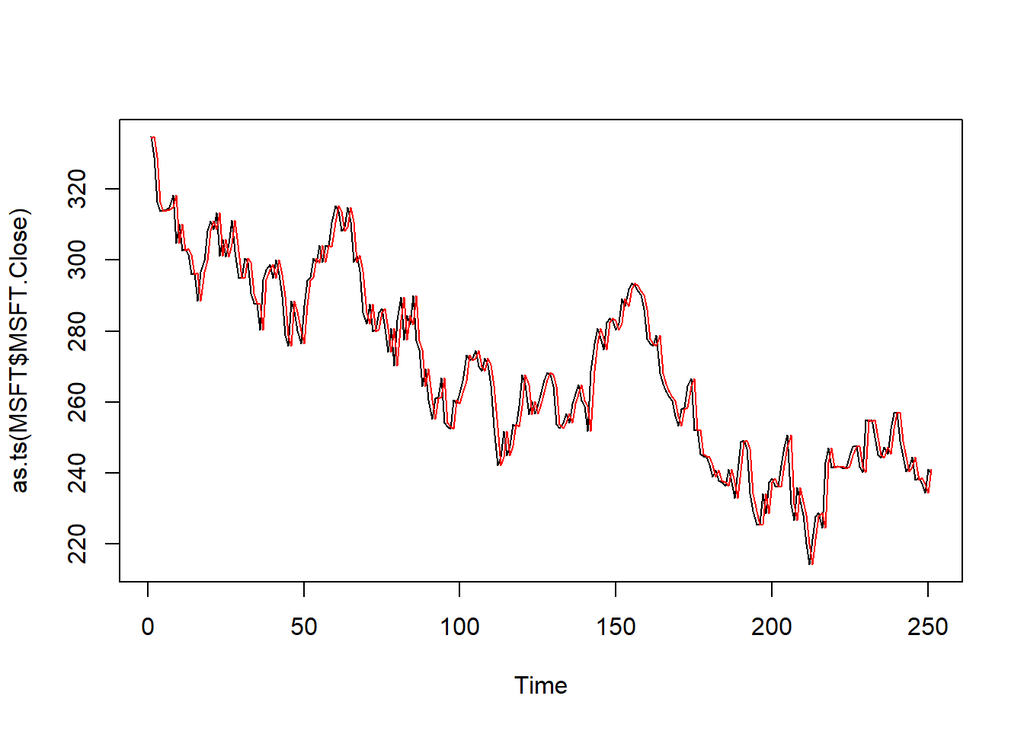

```r
plot(as.ts(MSFT$MSFT.Close))
lines(modelfit$fitted,col="red")
```

The Box-Ljung test results for different lag values indicate that there is no significant autocorrelation present in the residuals of the ARIMA model, as indicated by the high p-values (p > 0.05). This suggests that the residuals exhibit no systematic patterns over time. Additionally, the plot overlays the fitted values (red line) of the ARIMA model on the actual train set stock close price data.

**ARIMA Results** Now with the model fitted we can proceed to forecast our daily close price values to the future. We focus on forecasting the close stock price for the next 30 days or an average month.

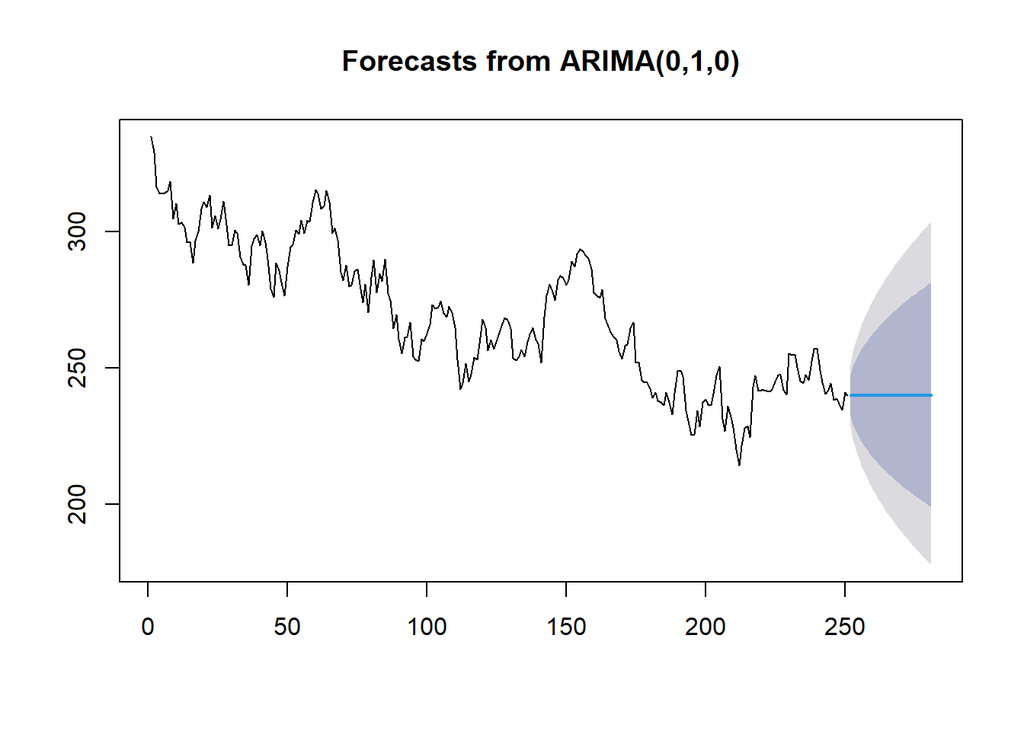

```r
# Forecast future values using the neural network model
plot(forecast(modelfit,h=30))
```

The plot displays the forecasted closing prices for the next 30 days based on the ARIMA model.

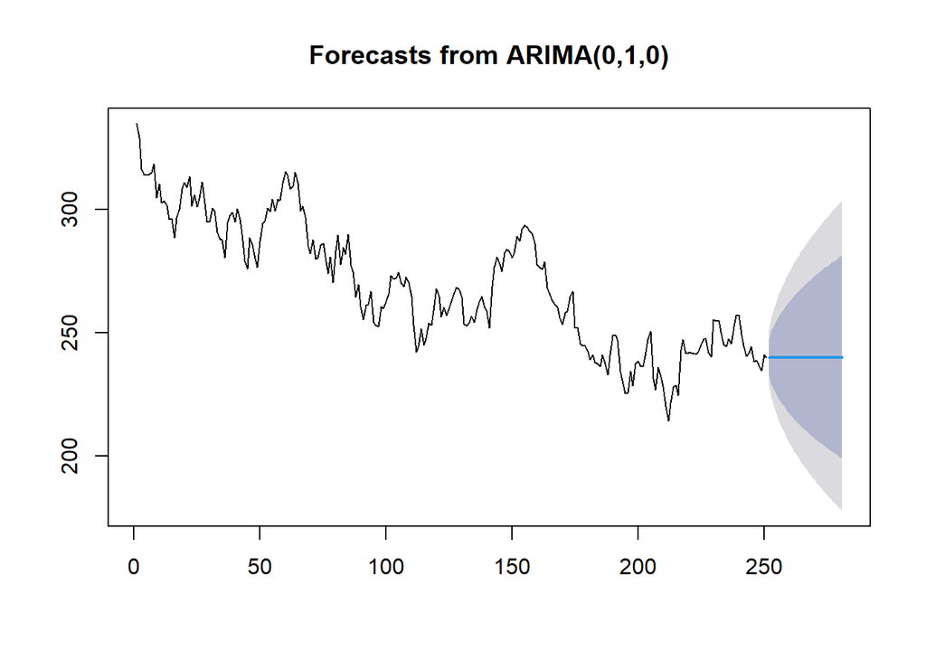

```r
# Forecast future values using the neural network model
price_forecast <- forecast(modelfit,h=30)
plot(price_forecast)
```

```r
head(price_forecast$mean)
```

```
## Time Series:
## Start = 252
## End = 257
## Frequency = 1
## [1] 239.82 239.82 239.82 239.82 239.82 239.82
```

```r
# Dividing the data into train & test sets , Applying the model
N = length (MSFT$MSFT.Close)
n = 0.8*N
train = MSFT$MSFT.Close[1:n, ]
test = MSFT$MSFT.Close[(n+1):N,]
trainarimafit <- auto.arima(train$MSFT.Close ,lambda= "auto")
summary(trainarimafit)
```

```
## Series: train$MSFT.Close
## ARIMA(1,1,1)
## Box Cox transformation: lambda= 1.407016
##
## Coefficients:
##          ar1      ma1
##       0.8576  -0.8971
## s.e.  0.3033   0.2673
##
## sigma^2 = 3430:  log likelihood = -1091.35
## AIC=2188.71   AICc=2188.83   BIC=2198.59
##
## Training set error measures:
##                      ME     RMSE      MAE        MPE     MAPE      MASE
## Training set -0.6671446 5.891735 4.685217 -0.2649952 1.709539 0.9943986
##                     ACF1
## Training set -0.02494239
```

```r
predlen= length(test)
trainarima_fit <- forecast(trainarimafit, h= predlen)
```

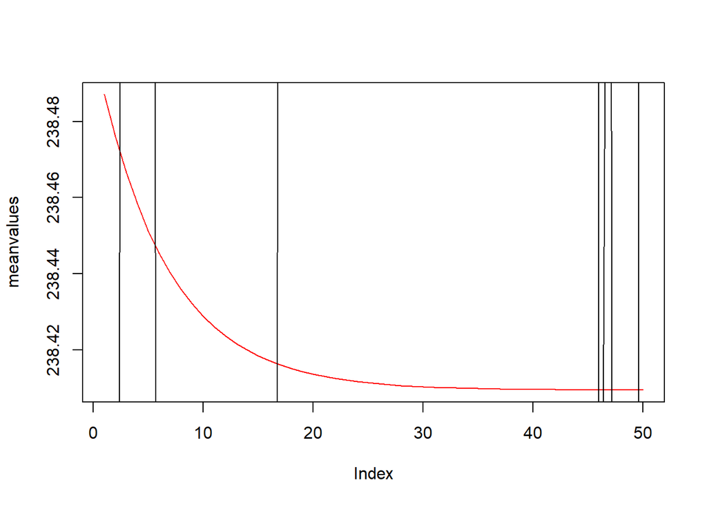

```r
#Plotting mean predicted  values vs real data
meanvalues<- as.vector(trainarima_fit$mean)
precios <- as.vector(test$MSFT.Close)
plot(meanvalues, type = "l",col="red")
lines(precios, type = "l")
```

```r
#dev.off()
```

```r
#Fitting nnetar
 lambda = BoxCox.lambda(MSFT$MSFT.Close)
 dnn_fit = nnetar(MSFT[,4],lambda=lambda)
 dnn_fit
```

```
## Series: MSFT[, 4]
## Model:  NNAR(1,1)
## Call:   nnetar(y = MSFT[, 4], lambda = lambda)
##
## Average of 20 networks, each of which is
## a 1-1-1 network with 4 weights
## options were - linear output units
##
## sigma^2 estimated as 10.4
```

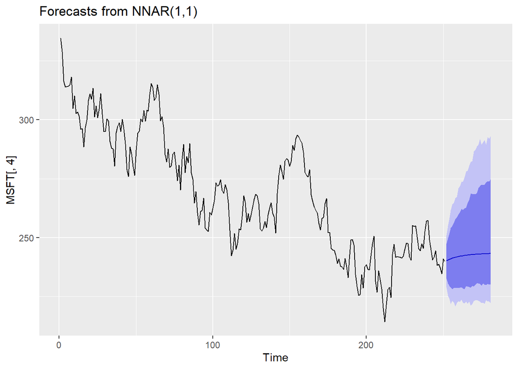

```r
 fcast = forecast(dnn_fit,PI=T,h=30)
 autoplot(fcast)
```

```r
# Calculate accuracy metrics for the neural network model
 accuracy(dnn_fit)
```

```
##                       ME     RMSE      MAE         MPE     MAPE      MASE
## Training set 0.006576859 5.773343 4.546834 -0.04497814 1.703709 0.9854515
##                     ACF1
## Training set -0.01829659
```

**Accuracy:** ME (Mean Error): The ME is approximately 0.0065, indicating a slight tendency for the model to slightly underestimate the actual close prices, on average.

RMSE (Root Mean Square Error): With an RMSE value of around 5.77, the average magnitude of errors in the predictions is relatively moderate, suggesting a reasonable fit of the model to the data.

MAPE (Mean Absolute Percentage Error): With a MAPE value of approximately 1.70%, the average percentage deviation of the predictions from the actual values is relatively low, indicating reasonable accuracy.

MASE (Mean Absolute Scaled Error): The MASE value of about 0.985 suggests that the model performs similarly to a naive benchmark model, such as a random walk, indicating a comparable level of performance.

**Overall Interpretation:** Overall, the NNAR model applied to the dataset demonstrates reasonably good performance in terms of accuracy measures. While there is a slight bias in the predictions, with a tendency to slightly underestimate actual close prices on average, the overall magnitude of errors, as reflected by RMSE and MAE, is moderate. Additionally, the model’s performance, as measured by MASE and MAPE, suggests that it performs comparably to a naive benchmark model, indicating a reasonable level of accuracy

### Apple (APPL)

```r
getSymbols("AAPL",src="yahoo",from="2022-01-01",to = "2022-12-31")
```

```
## [1] "AAPL"
```

```r
head(AAPL)
```

```
##            AAPL.Open AAPL.High AAPL.Low AAPL.Close AAPL.Volume AAPL.Adjusted
## 2022-01-03    177.83    182.88   177.71     182.01   104487900      179.7246
## 2022-01-04    182.63    182.94   179.12     179.70    99310400      177.4436
## 2022-01-05    179.61    180.17   174.64     174.92    94537600      172.7236
## 2022-01-06    172.70    175.30   171.64     172.00    96904000      169.8403
## 2022-01-07    172.89    174.14   171.03     172.17    86709100      170.0081
## 2022-01-10    169.08    172.50   168.17     172.19   106765600      170.0279
```

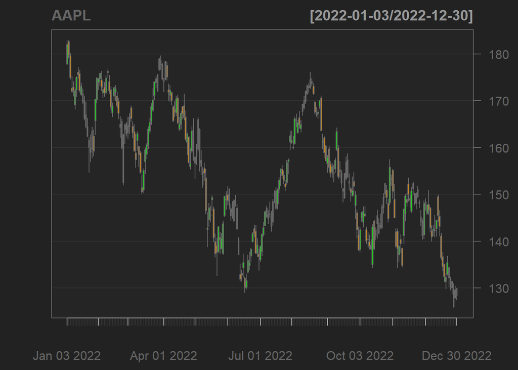

```r
chartSeries(AAPL,TA = NULL)
```

```r
## ADF Test
print(adf.test(AAPL$AAPL.Close))
```

```
##
##  Augmented Dickey-Fuller Test
##
## data:  AAPL$AAPL.Close
## Dickey-Fuller = -2.6105, Lag order = 6, p-value = 0.3187
## alternative hypothesis: stationary
```

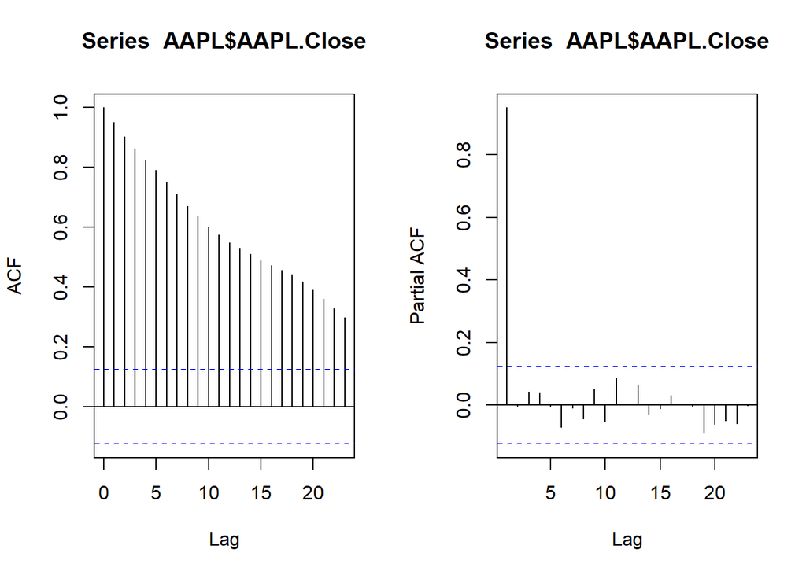

```r
## Plot ACF and PACF

par(mfrow = c(1, 2))
acf(AAPL$AAPL.Close)
pacf(AAPL$AAPL.Close)
```

```r
par(mfrow = c(1, 1))

#dev.off()
```

**ACF Analysis:**

**PACF Analysis:**

- The PACF plot shows a single significant spike at lag 1, exceeding the confidence bounds. There are no other significant spikes at higher lags.

This suggests that there might be a short-term dependence in the AAPL stock returns. In other words, the previous day’s return (lag 1) might have a slight influence on the current day’s return. However, there’s no evidence of significant dependence on returns from further past days.

**Overall Interpretation:**

We then analyzed the p-values to assess the validity of the ARIMA model’s assumptions.

```r
## Applying auto.arima() to the dataset
modelfit <-auto.arima(AAPL$AAPL.Close, lambda = "auto")
summary(modelfit)
```

```
## Series: AAPL$AAPL.Close
## ARIMA(0,1,0)
## Box Cox transformation: lambda= 1.837472
##
## sigma^2 = 53459:  log likelihood = -1715.57
## AIC=3433.14   AICc=3433.15   BIC=3436.66
##
## Training set error measures:
##                      ME    RMSE      MAE        MPE     MAPE      MASE
## Training set -0.2070953 3.40321 2.642705 -0.1591166 1.729245 0.9961647
##                     ACF1
## Training set -0.01658435
```

[figure not shown]

```r
# Diagnostics on Residuals
plot(resid(modelfit),ylab="Residuals",main="Residuals(Arima(5,1,2)) vs. Time")
```

[figure not shown]

```r
# Histogram of Residuals & Normality Assumption
hist(resid(modelfit),freq=F,ylim=c(0,9500),main="Histogram of Residuals")
e=resid(modelfit)
curve(dnorm(x, mean=mean(e), sd=sd(e)), add=TRUE, col="darkred")
```

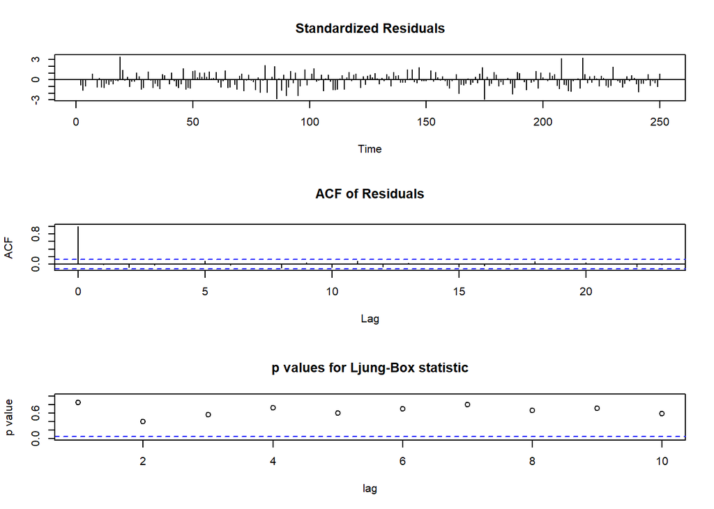

```r
# Diagnostics tests for Arima
tsdiag(modelfit)
```

Having our new ARIMA model applied and analyzed we can plot the model prediction in a red line over the real train set stock close price.

```r
# Box test for lag=2
Box.test(modelfit$residuals, lag= 2, type="Ljung-Box")
```

```
##
##  Box-Ljung test
##
## data:  modelfit$residuals
## X-squared = 1.8489, df = 2, p-value = 0.3967
```

```r
Box.test(modelfit$residuals, type="Ljung-Box")
```

```
##
##  Box-Ljung test
##
## data:  modelfit$residuals
## X-squared = 0.03917, df = 1, p-value = 0.8431
```

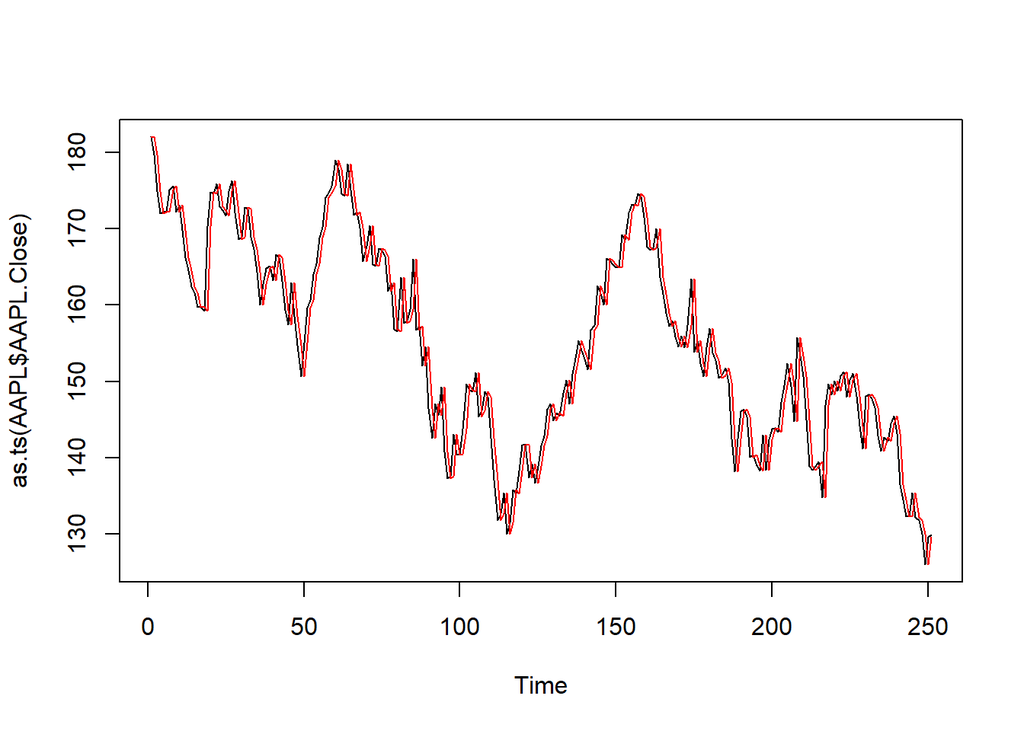

```r
plot(as.ts(AAPL$AAPL.Close))
lines(modelfit$fitted,col="red")
```

**ARIMA Results**

Now with the model fitted we can proceed to forecast our daily close price values to the future. We focus on forecasting the close stock price for the next 30 days or an average month.

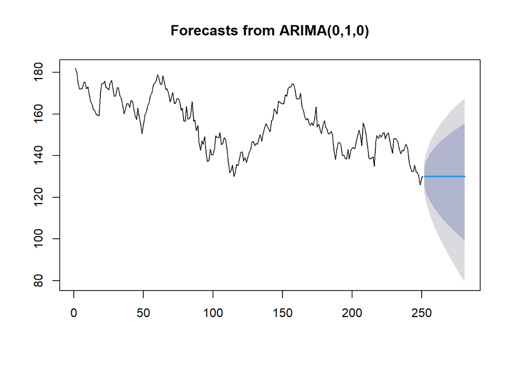

```r
plot(forecast(modelfit,h=30))
```

The solid line represents the point forecast, while the shaded area depicts the prediction interval.

- Point Forecast: This is the solid line in the forecast plot and represents the most likely closing price for each day in the next month according to the model.
- Prediction Interval: The shaded area surrounding the point forecast depicts a range within which the actual closing prices are likely to fall with an 80% confidence level. It indicates a narrower range compared to a typical 95% confidence interval.

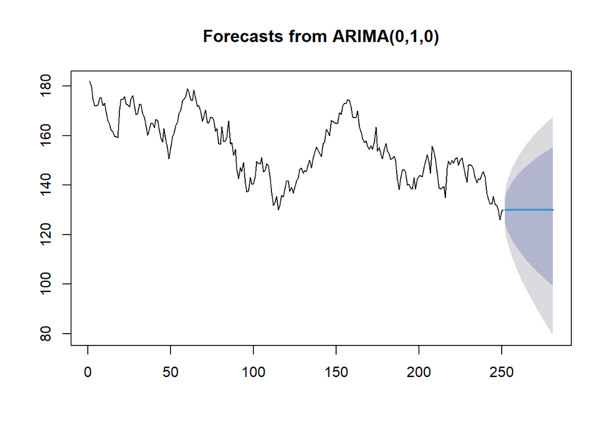

```r
price_forecast <- forecast(modelfit,h=30)
plot(price_forecast)
```

```r
head(price_forecast$mean)
```

```
## Time Series:
## Start = 252
## End = 257
## Frequency = 1
## [1] 129.93 129.93 129.93 129.93 129.93 129.93
```

```r
# Dividing the data into train & test sets , Applying the model
N = length (AAPL$AAPL.Close)
n = 0.8*N
train = AAPL$AAPL.Close[1:n, ]
test = AAPL$AAPL.Close[(n+1):N,]
trainarimafit <- auto.arima(train$AAPL.Close ,lambda= "auto")
summary(trainarimafit)
```

```
## Series: train$AAPL.Close
## ARIMA(0,1,0)
## Box Cox transformation: lambda= 1.617622
##
## sigma^2 = 5742:  log likelihood = -1143.6
## AIC=2289.19   AICc=2289.21   BIC=2292.49
##
## Training set error measures:
##                      ME     RMSE      MAE       MPE     MAPE      MASE
## Training set -0.1907374 3.335524 2.622862 -0.140878 1.686908 0.9952135
##                     ACF1
## Training set -0.01436719
```

```r
predlen= length(test)
trainarima_fit <- forecast(trainarimafit, h= predlen)
```

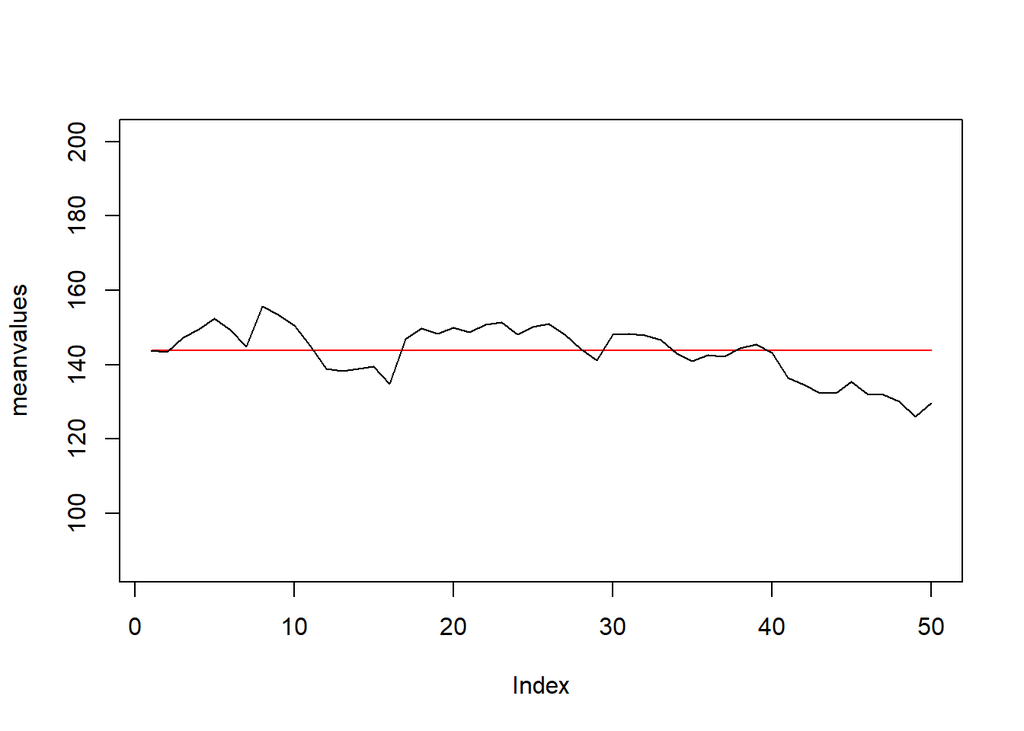

```r
#Plotting mean predicted  values vs real data
meanvalues<- as.vector(trainarima_fit$mean)
precios <- as.vector(test$AAPL.Close)
plot(meanvalues, type = "l",col="red")
lines(precios, type = "l")
```

```r
#dev.off()
```

```r
#Fitting nnetar
 lambda = BoxCox.lambda(AAPL$AAPL.Close)
 dnn_fit = nnetar(AAPL[,4],lambda=lambda)
 dnn_fit
```

```
## Series: AAPL[, 4]
## Model:  NNAR(1,1)
## Call:   nnetar(y = AAPL[, 4], lambda = lambda)
##
## Average of 20 networks, each of which is
## a 1-1-1 network with 4 weights
## options were - linear output units
##
## sigma^2 estimated as 51784
```

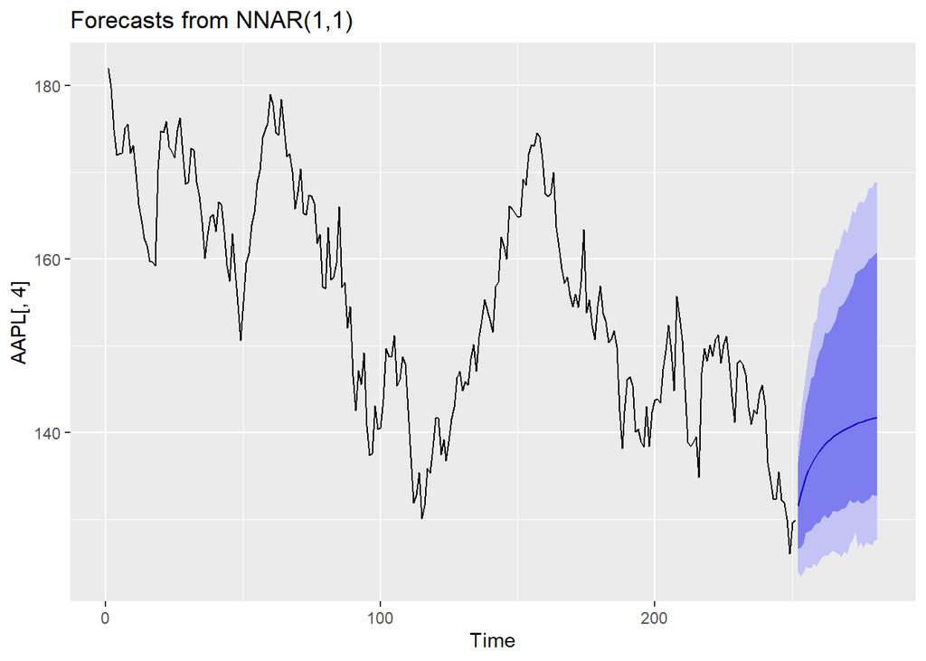

```r
 fcast = forecast(dnn_fit,PI=T,h=30)
 autoplot(fcast)
```

```r
 accuracy(dnn_fit)
```

```
##                       ME     RMSE      MAE        MPE    MAPE      MASE
## Training set -0.03110142 3.361123 2.612703 -0.0695912 1.71013 0.9848555
##                     ACF1
## Training set 0.004638985
```

**Accuracy**

ACF1 (Autocorrelation Function at Lag 1): 0.0046 suggests minimal autocorrelation in the errors, which is a positive sign.

```r
getSymbols("NEE",src="yahoo",from="2022-01-01",to = "2022-12-31")
```

```
## [1] "NEE"
```

```r
head(NEE)
```

```
##            NEE.Open NEE.High NEE.Low NEE.Close NEE.Volume NEE.Adjusted
## 2022-01-03    93.42    93.65   90.54     91.66    7864400     86.48953
## 2022-01-04    91.65    91.93   90.62     90.68    8379100     85.56481
## 2022-01-05    90.28    91.50   89.68     89.73    6722300     84.66841
## 2022-01-06    89.09    89.36   85.65     85.77   12658600     80.93179
## 2022-01-07    85.77    86.87   84.51     86.41   13359300     81.53569
## 2022-01-10    85.80    86.36   83.74     84.29   11378700     79.53527
```

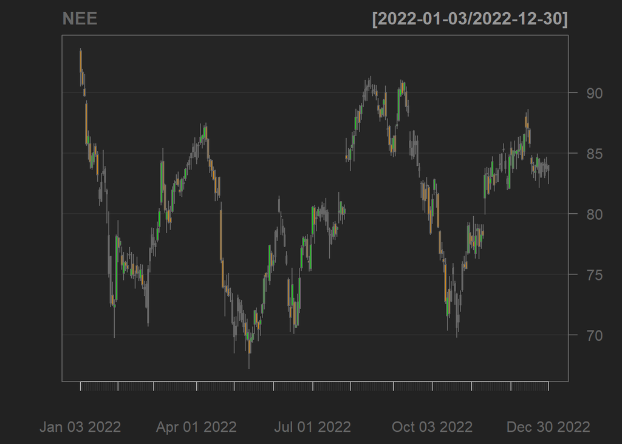

```r
chartSeries(NEE,TA = NULL)
```

```r
## ADF Test
print(adf.test(NEE$NEE.Close))
```

```
##
##  Augmented Dickey-Fuller Test
##
## data:  NEE$NEE.Close
## Dickey-Fuller = -2.8072, Lag order = 6, p-value = 0.2359
## alternative hypothesis: stationary
```

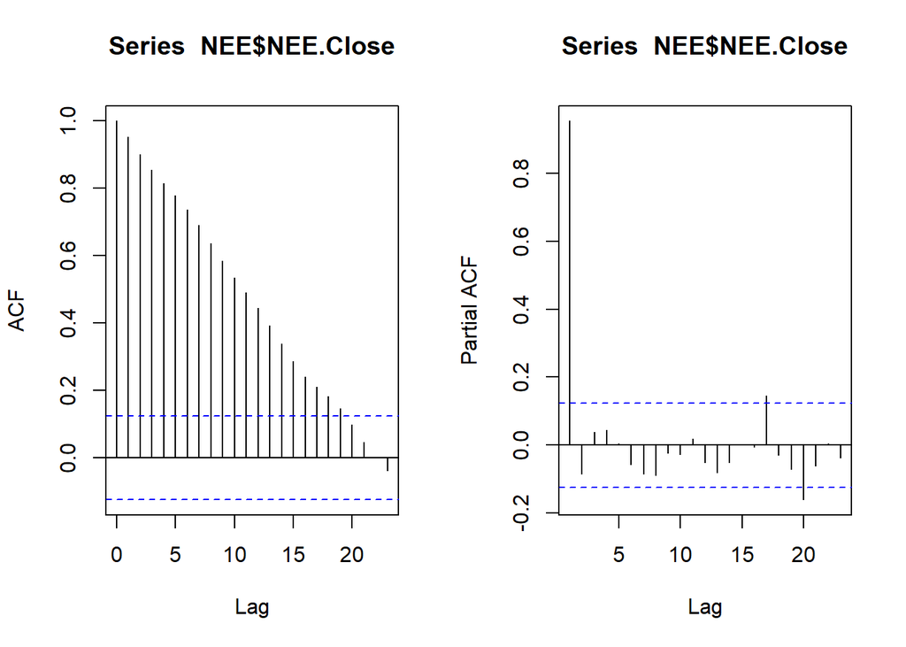

```r
## Plot ACF and PACF

par(mfrow = c(1, 2))
acf(NEE$NEE.Close)
pacf(NEE$NEE.Close)
```

```r
par(mfrow = c(1, 1))

#dev.off()
```

**ADF Test:**

- The ADF test statistic for NEE stock returns is calculated to be -2.8072, with a p-value of 0.2359.

Interpretation: With a p-value of 0.2359, we fail to reject the null hypothesis of non-stationarity at the 5% significance level. The result suggests that the series may exhibit stationary behavior, but it’s not statistically significant.

While there’s no definitive evidence to conclude that the NEE stock returns are stationary based on the ADF test alone, further analysis or alternative tests may be needed for confirmation.

**ACF Analysis:**

- The ACF plot for NEE stock returns gradually diminishes towards zero as the lag increases. However, some lags show spikes that exceed the confidence bounds.

**PACF Analysis:**

- The PACF plot for NEE stock returns shows a significant spike at lag 1, exceeding the confidence bounds. Additionally, lag 17 touches slightly above the positive confidence bound, and lag 20 touches slightly below the negative confidence bound.

Interpretation: This indicates short-term dependence on the previous day’s returns (lag 1), suggesting that yesterday’s performance might influence today’s returns. However, the significance of this influence diminishes rapidly for lags beyond the immediate previous day.

While there’s evidence of short-term dependence, particularly at lag 1, the influence of past returns on future returns quickly diminishes as we look further back in time. This supports the notion of a series with limited long-term memory or persistence.

**Overall Interpretation:**

```r
## Applying auto.arima() to the dataset
modelfit <-auto.arima(NEE$NEE.Close, lambda = "auto")
summary(modelfit)
```

```
## Series: NEE$NEE.Close
## ARIMA(1,1,1) with drift
## Box Cox transformation: lambda= 1.999927
##
## Coefficients:
##          ar1     ma1    drift
##       -0.854  0.9458  -2.9350
## s.e.   0.066  0.0414   7.9637
##
## sigma^2 = 14572:  log likelihood = -1551.71
## AIC=3111.42   AICc=3111.58   BIC=3125.5
##
## Training set error measures:
##                       ME     RMSE      MAE          MPE     MAPE     MASE
## Training set 0.004987396 1.508285 1.118939 -0.007761265 1.409496 0.988672
##                    ACF1
## Training set 0.02433287
```

[figure not shown]

```r
# Diagnostics on Residuals
plot(resid(modelfit),ylab="Residuals",main="Residuals(Arima(5,1,2)) vs. Time")
```

The plot of residuals from the ARIMA(1,1,1) model applied to the NEE stock closing prices indicates a relatively random pattern around zero, suggesting that the model adequately captures the underlying patterns in the data

[figure not shown]

```r
# Histogram of Residuals & Normality Assumption
hist(resid(modelfit),freq=F,ylim=c(0,9500),main="Histogram of Residuals")
e=resid(modelfit)
curve(dnorm(x, mean=mean(e), sd=sd(e)), add=TRUE, col="darkred")
```

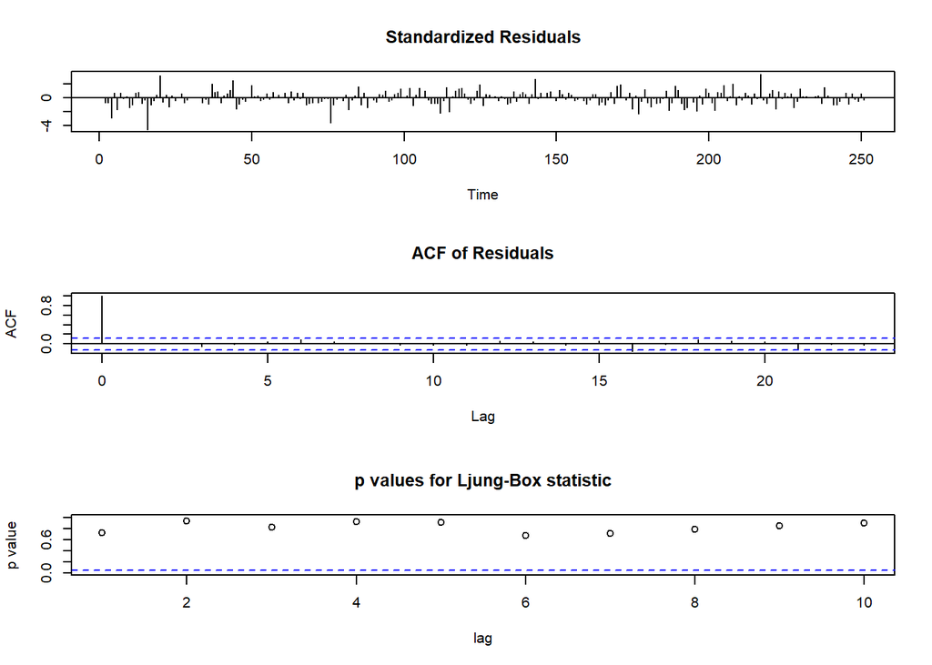

```r
# Diagnostics tests for Arima
tsdiag(modelfit)
```

```r
# Box test for lag=2
Box.test(modelfit$residuals, lag= 2, type="Ljung-Box")
```

```
##
##  Box-Ljung test
##
## data:  modelfit$residuals
## X-squared = 0.1347, df = 2, p-value = 0.9349
```

```r
Box.test(modelfit$residuals, type="Ljung-Box")
```

```
##
##  Box-Ljung test
##
## data:  modelfit$residuals
## X-squared = 0.12347, df = 1, p-value = 0.7253
```

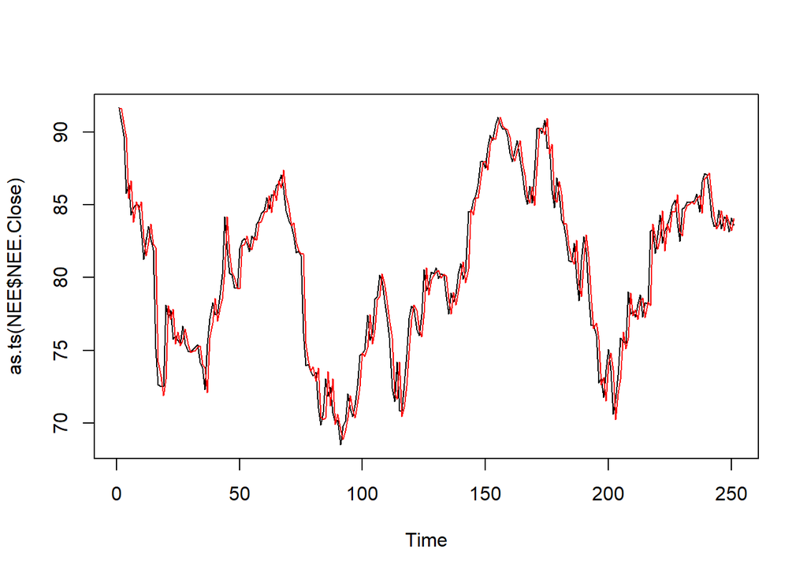

```r
plot(as.ts(NEE$NEE.Close))
lines(modelfit$fitted,col="red")
```

The Box-Ljung test for lag 2 yields an X-squared value of 0.1347 with a p-value of 0.9349, and for lag 1, an X-squared value of 0.12347 with a p-value of 0.7253, indicating no significant autocorrelation in the residuals. Additionally, the plot of actual versus fitted values shows a close alignment, suggesting that the model captures the underlying pattern in the data effectively.

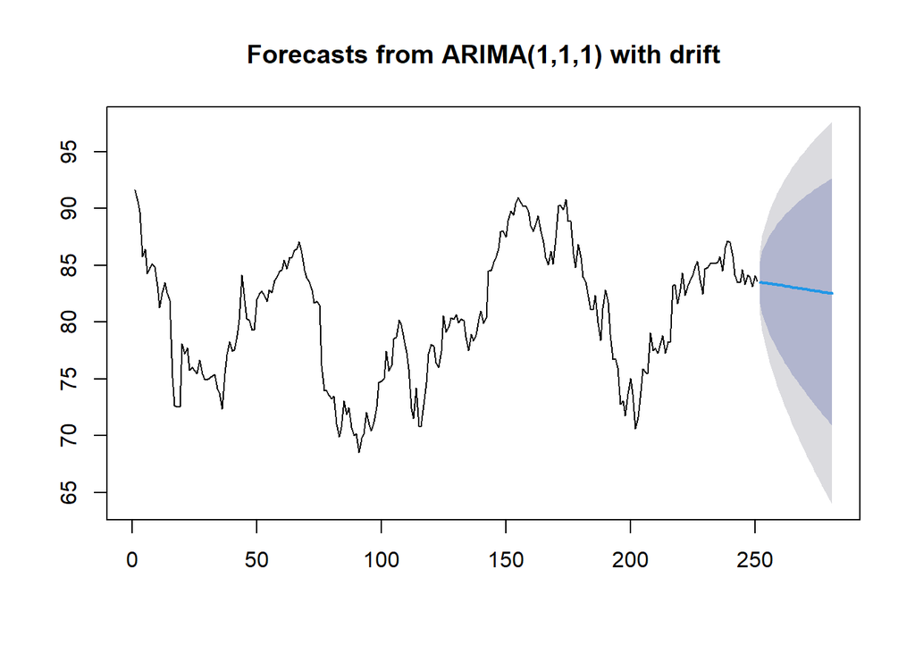

```r
plot(forecast(modelfit,h=30))
```

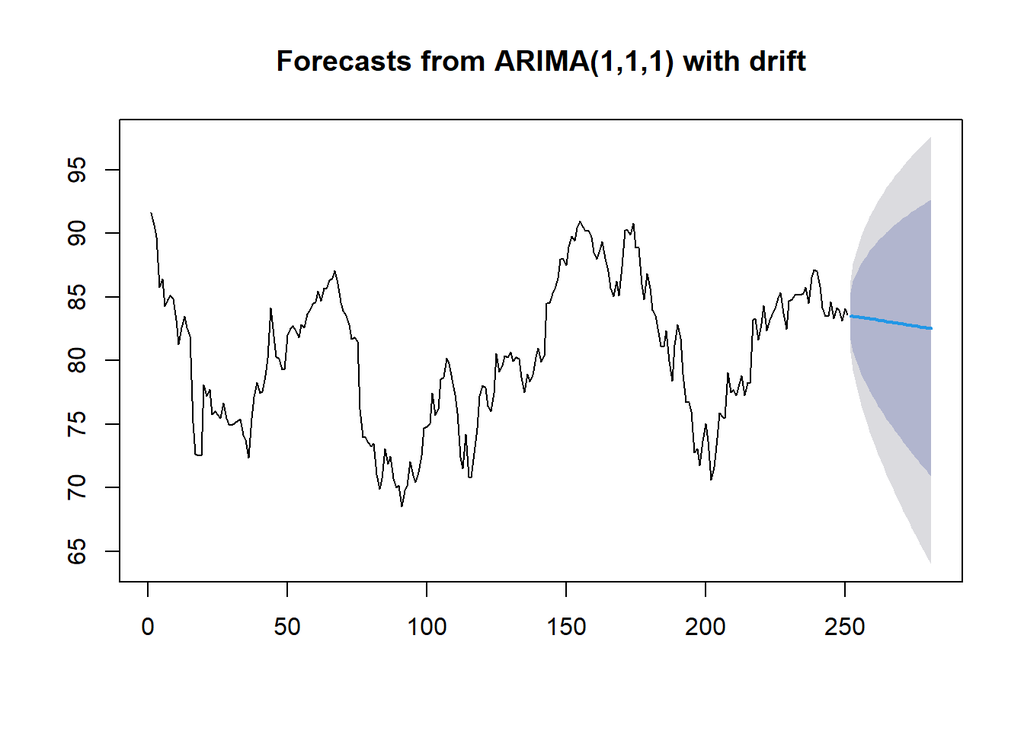

```r
price_forecast <- forecast(modelfit,h=30)
plot(price_forecast)
```

```r
head(price_forecast$mean)
```

```
## Time Series:
## Start = 252
## End = 257
## Frequency = 1
## [1] 83.51578 83.52256 83.45157 83.44700 83.38564 83.37278
```

```r
# Dividing the data into train & test sets , Applying the model
N = length (NEE$NEE.Close)
n = 0.8*N
train = NEE$NEE.Close[1:n, ]
test = NEE$NEE.Close[(n+1):N,]
trainarimafit <- auto.arima(train$NEE.Close ,lambda= "auto")
summary(trainarimafit)
```

```
## Series: train$NEE.Close
## ARIMA(1,1,1)
## Box Cox transformation: lambda= 1.999927
##
## Coefficients:
##           ar1     ma1
##       -0.8243  0.9319
## s.e.   0.0838  0.0539
##
## sigma^2 = 14956:  log likelihood = -1237.96
## AIC=2481.92   AICc=2482.05   BIC=2491.8
##
## Training set error measures:
##                       ME     RMSE      MAE        MPE     MAPE      MASE
## Training set -0.07796723 1.529938 1.137307 -0.1117552 1.437858 0.9870221
##                    ACF1
## Training set 0.04778891
```

```r
predlen= length(test)
trainarima_fit <- forecast(trainarimafit, h= predlen)
```

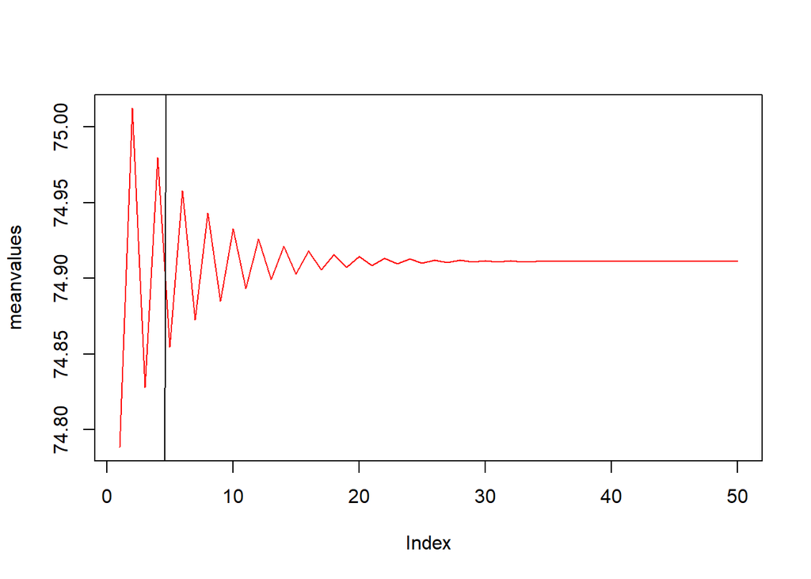

```r
#Plotting mean predicted  values vs real data
meanvalues<- as.vector(trainarima_fit$mean)
precios <- as.vector(test$NEE.Close)
plot(meanvalues, type = "l",col="red")
lines(precios, type = "l")
```

```r
#dev.off()
```

```r
#Fitting nnetar
 lambda = BoxCox.lambda(NEE$NEE.Close)
 dnn_fit = nnetar(NEE[,4],lambda=lambda)
 dnn_fit
```

```
## Series: NEE[, 4]
## Model:  NNAR(1,1)
## Call:   nnetar(y = NEE[, 4], lambda = lambda)
##
## Average of 20 networks, each of which is
## a 1-1-1 network with 4 weights
## options were - linear output units
##
## sigma^2 estimated as 14354
```

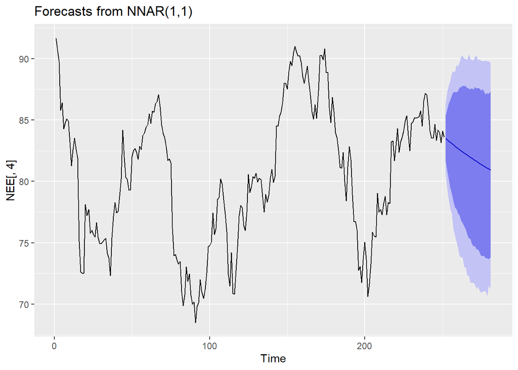

```r
 fcast = forecast(dnn_fit,PI=T,h=30)
 autoplot(fcast)
```

```r
 accuracy(dnn_fit)
```

```
##                       ME    RMSE      MAE         MPE     MAPE      MASE
## Training set -0.01446393 1.51098 1.115275 -0.05522266 1.404976 0.9854339
##                   ACF1
## Training set 0.1113707
```

**Accuracy:**

ME (Mean Error): The ME is approximately -0.014, indicating a slight tendency for the model to slightly overestimate the actual close prices, on average.

RMSE (Root Mean Square Error): With an RMSE value of around 1.51, the average magnitude of errors in the predictions is relatively low, suggesting a reasonable fit of the model to the data.

MAE (Mean Absolute Error): The MAE value of about 1.12 represents the average absolute deviation of the predictions from the actual close prices, providing insight into the typical magnitude of errors.

MAPE (Mean Absolute Percentage Error): With a MAPE value of approximately 1.41%, the average percentage deviation of the predictions from the actual values is relatively low, indicating reasonable accuracy.

MASE (Mean Absolute Scaled Error): The MASE value of about 0.986 suggests that the model performs similarly to a naive benchmark model, such as a random walk, indicating a comparable level of performance.

**Overall Interpretation:** Overall, the NNAR model applied to the NEE stock close prices demonstrates reasonably good performance in terms of accuracy measures. Despite a slight bias in the predictions, indicated by the negative ME and MPE, the overall magnitude of errors, as reflected by RMSE and MAE, is relatively low. Additionally, the model’s performance, as measured by MASE, suggests that it performs comparably to a simple benchmark model

```r
getSymbols("XOM",src="yahoo",from="2022-01-01",to = "2022-12-31")
```

```
## [1] "XOM"
```

```r
head(XOM)
```

```
##            XOM.Open XOM.High XOM.Low XOM.Close XOM.Volume XOM.Adjusted
## 2022-01-03    61.24    63.60   61.21     63.54   24282400     58.55364
## 2022-01-04    64.13    66.19   64.10     65.93   38584000     60.75608
## 2022-01-05    66.50    67.61   66.48     66.75   34033300     61.51173
## 2022-01-06    68.00    68.48   67.07     68.32   30668500     62.95852
## 2022-01-07    68.52    69.18   67.98     68.88   23985400     63.47457
## 2022-01-10    68.97    69.17   67.95     68.47   22760300     63.09676
```

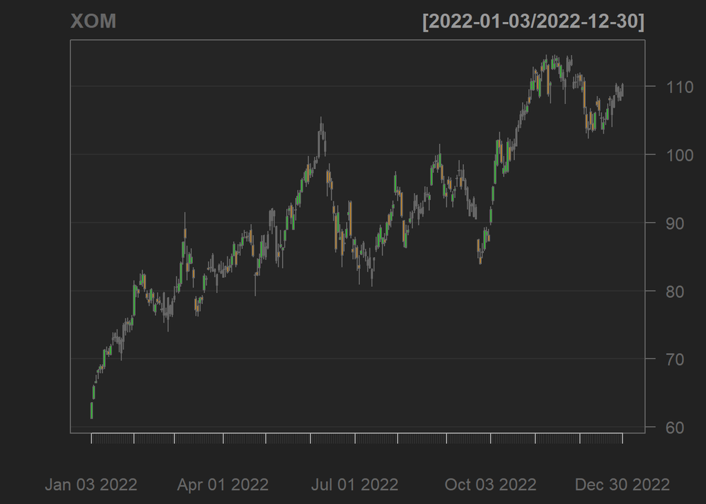

```r
chartSeries(XOM,TA = NULL)
```

```r
## ADF Test
print(adf.test(XOM$XOM.Close))
```

```
##
##  Augmented Dickey-Fuller Test
##
## data:  XOM$XOM.Close
## Dickey-Fuller = -2.9808, Lag order = 6, p-value = 0.1628
## alternative hypothesis: stationary
```

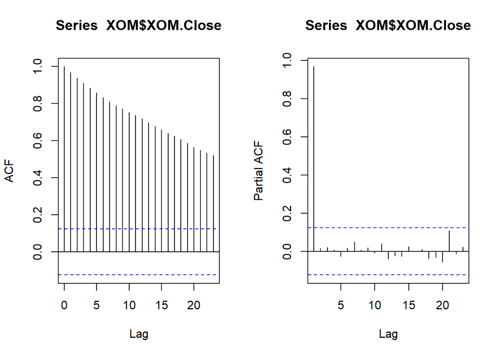

```r
## Plot ACF and PACF

par(mfrow = c(1, 2))
acf(XOM$XOM.Close)
pacf(XOM$XOM.Close)
```

```r
par(mfrow = c(1, 1))

#dev.off()
```

**ADF Test:** The ADF test statistic for XOM stock returns is calculated to be -2.9808, with a p-value of 0.1628. Interpretation: With a p-value of 0.1628, we fail to reject the null hypothesis of non-stationarity at the 5% significance level. While the result suggests potential stationary behavior, it’s not statistically significant.

Interpretation: This indicates short-term dependence on the previous day’s returns (lag 1), suggesting that yesterday’s performance might influence today’s returns. However, the significance of this influence diminishes rapidly for lags beyond the immediate previous day.

While there’s evidence of short-term dependence, particularly at lag 1, the influence of past returns on future returns quickly diminishes as we look further back in time.